# The analysis of safety data from clinical trials

# Introduction

Clinical trials are usually designed to address a specific question about the efficacy of a drug in treating a particular condition. Since such questions of efficacy are usually well-formed and since the clinical trials are designed to answer them, the analysis of the resulting data is usually a straightforwared, prespecified analysis using a standard statistical technique to compare, say, mean values, or the duration of survival, or the patients in the different treatment groups.

However, the bulk of the data that are collected in clinical trials relate not to the *efficacy* of the drug, but to its *safety*. Safety data will typically include data on the patients’ vital signs, adverse events, concomitant medications, and clinical laboratory data. Most adverse events, whether or not related to the drug, tend to be uncommon so that the data tend to be sparse. The laboratory data often have skewed distributions and are subject to outliers. For safety data then, unlike efficacy, the questions are typically not well-defined, some of them will not be known until the data have been studied in some detail, and the data are of mixed types and messy. For these reasons, statisticians have tended to be cautious in the analysis of safety data, leaving interpretation to clinicians.

Published statistical guidance for clinical trials (1998) summarizes this position:

> The investigation of safety and tolerability is a multidimensional problem. Although some specific adverse effects can usually be anticipated and specifically monitored for any drug, the range of possible adverse effects is very large, and new and unforeseeable effects are always possible. Further, an adverse event experienced after a protocol violation, such as use of an excluded medication, may introduce a bias. This background underlies the statistical difficulties associated with the analytical evaluation of safety and tolerability of drugs, and means that conclusive information from confirmatory clinical trials is the exception rather than the rule.

# Extreme values of laboratory data

The rest of this article focusses on the laboratory data. As already mentioned, the data tend to be far from normally distributed and subject to outliers. In fact, it is usually the outliers that indicate safety issues, as supported by the following observations.

Since it is the extreme values of laboratory variables that tend to indicate toxicity, it is usual for them to have an associated *upper limit of normal* (ULN) and *lower limit of normal* (LLN). The way in which these quantities are calculated can vary from laboratory to laboratory, but they represent high and low quantiles, such as the $5^{th}$ and $95^{th}$ percentiles, of the distribution. Thus any observation that is above the ULN, or some multiple of it, is considered to be abnormal and potentially relating to a safety issue.

The clinical trial statistician concerned with efficacy is concerned with characterizing the *expected* response patients have to the drug. When it comes to safety, it is characterization of the *unexpected* responses, the extreme values, that is important. As such, measures of central tendency such as means and medians, and the familiar tools in the clinical trial statistician’s toolbox – analysis of variance, regression, tests for equality of means, etc. – are useless in the interpretation of clinical safety data.

# An illustrative example

To illustrate the problems that can arise, consider the case of troglitazone, a drug used for the treatment of diabetes, and liver toxicity. An FDA review (1999) of the available data states:

> Mean [ALT and AST] levels fell in patients receiving troglitazone in phase 3 trials… It was also stated that 2.2% of patients in phase 3 trials had a transaminase (ALT or AST) level exceeding $3 \times ULN$… What was not appreciated by [FDA] was that many of the patients classified as ALT $> 3\times ULN$ actually had ALT values that were VERY much higher than $3\times ULN$… 23 patients had treatment-emergent ALT values over $3\times ULN$… In 14 of these 23 patients, the ALT value exceeded $8\times ULN$… and in 5/23 patients the ALT value exceeded $30\times ULN$.

The review goes on to describe how, once troglitazone was on the market, cases of ‘frank liver failure’ were reported in association with the drug. Further, in a postmarketing clinical trial, a patient developed irreversible liver damage and ultimately died. The drug was withdrawn from the market.

The apparent toxicity of troglitazone was not at all predicted by the central tendency of the distributions of ALT and AST – the means and medians went *down*, intuitively suggesting a beneficial effect of the drug on the liver! It was the extreme values of ALT and AST that contained the useful information. Making inferences about the potential for liver toxicity by looking at the mean would be misleading and dangerous.

# A novel statistical approach

Clinical safety data can’t be the only setting in which it is the extreme values that are of interest. In fact, methods for the analysis of extreme values have a long history: Gumbel (1958) traces attempts by statisticians to handle extreme value problems back to the early $18^{th}$ century, but it was in 1928 that Fisher and Tippett (1928) published a landmark paper which led to a flurry of research which continues today.

The first full length book on extreme value methods, by Gumbel, appeared in 1958 (1958). Many of the statistical applications Gumbel faced were hydrological in nature, and he wrote that

> Until recent years, engineers employed purely empirical procedures for the analysis of hydrological data and, especially, the evaluation of the frequencies of floods and droughts. These studies led practically nowhere until the statistical nature of the problem was recognized. Even then the results were meager and disappointing. Hence the claim that “sound engineering judgment” is superior to statistics, a statement which may have been true as long as the adequate statistical method was unknown. At present the statistical nature of these problems has been realized and the empirical procedures are slowly being replaced by methods derived from the theory of extreme values.

Hydrology, though, is not the only field in which it is the extreme values of the data that are of interest. Beirlant et al (2004) cite examples of extreme value methods being used in the fields of geology, metallurgy, the study of network traffic, demography, economics, geography, travel, traffic, psychology and others.

# Application to clinical trial safety data

Different extreme value models exist for dealing with data arising in a variety of settings. In the clinical trial setting, we typically have a fairly small number of observed values from each of several dozen or a few hundred patients. Here, methods which enable us to characterize the upper tail of the distribution of the data are appropriate and the appropriate tool is known as the *generalized Pareto* (GP) distribution.

The GP distribution has two parameters, one of which ($\sigma$) controls the scale of the distribution, the other of which ($\xi$) controls how heavy the tail is. By examining how the values of $\sigma$ and $\xi$ depend on the drug and dose, we can form an idea of the strength of evidence for treatment and dose-response effects, and of the nature of those relationships. Plots of the distribution for values of $\xi$ being $-\frac{1}{4}, 0$ and $\frac{1}{2}$ are shown in the following figure.

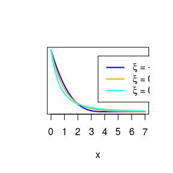

The generalized Pareto distribution with $\sigma = 1$ and $\xi$ being $-\frac{1}{4}, 0$ and $\frac{1}{2}$. Small values of $\xi$ result in short-tailed distributions and large values of $\xi$ result in heavy tails and thus greater probability of outliers.

The parameters in the GPD do not have a straightforward physical interpretation. In order to communicate the analysis to clinical colleagues, it is more useful to work with predictions from the fitted models. For example, we can use fitted models to predict how large the values that we see are likely to get if we expose larger numbers of patients to the experimental drug, or we can predict quantities such as the probability of any particular value being above *ULN*, *3ULN* or some other multiple.

# Example

A clinical trial collected data from patients receiving one of four different doses of an experimental drug. There were approximately 160 patients in each dose group. The doses are ordered such that Dose A is the lowest and Dose D is the highest. The ULN for ALT is 36 international units per litre (U/L). A detailed analysis of this example is provided by Southworth and Heffernan (2012).

The figure below shows baseline (i.e. pre-treatment) values of ALT against the on-treatment values. It can be seen that there are some outliers in the on-treatment values, particularly in the patients receiving Dose D. However, there are only a handful of large observations, and it is not clear if there is a tendency for outliers to occur in some of the lower dose groups. How concerned should we be about the large ALT values in group D?

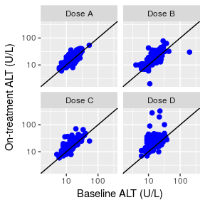

Plots of pre-treatment values versus on-treatment values in each dose group. The reference lines are lines of identity – a point above the line indicates an increase from baseline, and point below the line indicates a decrease.

The baseline and on-treatment values are clearly related to each other: higher baselines values are associated with higher on-treatment values. As such, it makes sense to eliminate the effect of baseline and apply extreme value modelling to any remaining variation. Since the outliers in the shiftplots above are not compatible with the data having come from a normal distribution, we use a robust regression method that is not unduly influenced by them. Plots of the residuals from the model (that is, what remains after the baseline effect has been removed) are displayed by Dose group in the following boxplots.

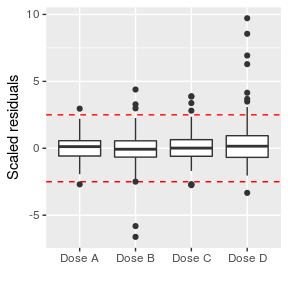

Boxplots of residuals from using robust regression to eliminate the baseline effect. If the residuals were from a normal distribution, we would expect them to mostly fall between about -2.5 and 2.5 – within the red dashed lines. Clearly there are outliers indicating that the residuals come from a heavy-tailed distribution. A dose-response relationship now becomes more clear.

In fitting extreme value models to the residuals displayed in the boxplots, it was found that the model that allowed the shape parameter to depend on log *Dose* was the best fit to the data. In order to interpret the model, we simulate values from it and then re-apply the baseline effect.

In general, we will likely be interested in just how high ALT is likely to get on each dose if we treat increasing numbers of patients. To address this question, we compute *return levels*. The $M$-patient return level is defined as the level of ALT likely to be exceeded only once every *M* patients observed. The figure below displays the estimated 1000-patient return levels for ALT – that is, the values of ALT likely to be exceeded only once every 1000 patients. The theory of extreme values allows us to estimate these quantities even though we have data on only 160 patients per dose.

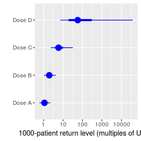

Estimated 1000-patient return levels for ALT at each dose. The heavy line segments are 50% confidence intervals, and the lighter segments are 90% intervals.

In the figure above, the dose response effect is clearly visible and the model indicates that if 1000 patients were to take Dose D, we should expect one of them to have an ALT greater than $50\times ULN$. Such high values of ALT can be observed in practice. However, the 90% interval estimate for Dose D contains values of ALT so high that it is unlikely they ever could be observed because either the patient would experience symptoms and stop taking the drug, the patient’s doctor would notice the change in ALT and stop the drug, or the patient would die.

[output not shown]

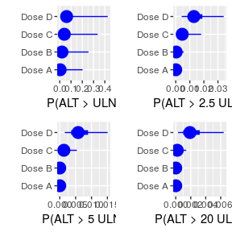

Estimated probabilities of ALT exceeding multiples of ULN with 50% and 90% confidence intervals. Note that the horizontal axes vary from plot to plot.

In the above figure, we can again clearly see the dose-response relationship that the drug appears to have on ALT. Of particular note, the model suggests that Dose D could result in an $ALT > 20\times ULN$ in approximately 1 in 400 patients, though there is no obvious cause for concern for Dose A.

In practice, it is known that the incidence of severe liver-related adverse events such as jaundice and hepatitis that occur with Dose D is approximately 1 in 500 patients whereas there is no evidence that such events occur with Dose A.

# Conclusion

Clinical trial safety data are complicated, messy and high-dimensional, and the traditional statistical methods that are useful for the analysis of efficacy data are of little or no use in the context of safety. These observations have led to the belief that statisticians have little of value to add to the interpretation of such data. However, recent experiences suggest that the field is ripe for more statistical input, and clinical trial statisticians would benefit from looking further afield than the set of tools they are taught on typical medical statistics courses, or in the clinical trials textbooks.

Application of extreme value modelling to laboratory and other clinical trial safety data suggests it might be the case that “the statistical nature of these problems has been realized”" and we are now embarking on a period during which *sound clinical judgement* will slowly be replaced by methods derived from the theory of extreme values.

# References

Beirlant, J., Y. Goegebeur, J. Segers, and J. Teugels. 2004. *Statistics of Extremees: Theory and Applications*. Wiley.

Fisher, R. A., and L. H. C. Tippett. 1928. “Limiting Forms of the Frequency Distribution of the Largest or Smallest Member of the Sample.” *Proceedings of the Cambridge Philosophical Society* 24.

Gumbel, E. J. 1958. *Statistics of Extremes*. Columbia University Press.

Harmonisation, International Conference on. 1998. *Statistical Principles for Clinical Trials, Ich Topic E9*. EMEA: Canary Wharf, London.

Southworth, H., and J. E. Heffernan. 2012. “Extreme Value Modelling of Laboratory Safety Data from Clinical Studies.” *Pharmaceutical Statistics*.

U.S. Food and Drugs Administration. 1999. “Medical Reviewer’s Final Report on Troglitazone.” http://www.accessdata.fda.gov/drugsatfda_docs/nda/99/20720S12S14_Rezulin_medr_P2.pdf.